# Hands-on Exercise 4b: Visualising Statistical Analysis

Author

Andy Tai

Published

May 3, 2026

Modified

May 3, 2026

## 1 Learning Outcome

This hands-on exercise focuses on:

- ggstatsplot package to create visual graphics with rich statistical information,
- performance package to visualise model diagnostics, and
- parameters package to visualise model parameters

## 2 Getting Started

**Installing and loading libraries**

- Use the pacman package to check, install and launch the R packages **ggstatplot** and **tidyverse**.
- [ggstatsplot](https://www.indrapatil.com/ggstatsplot/) is an extension of [ggplot2](https://ggplot2.tidyverse.org/) package for creating graphics with details from statistical tests included in the information-rich plots themselves.

```r
pacman::p_load(ggstatsplot, tidyverse, nortest, ggdist)
```

**Importing data**

- The code chunk below uses [read_csv()](https://readr.tidyverse.org/reference/read_delim.html) of **readr** package to import Exam_data.csv data file into R and save it as an tibble data frame called `exam_data`.

```r
exam <- read_csv("data/Exam_data.csv")
```

**Understanding the data**

- The data is a tibble dataframe and contains 322 observations across 7 attributes.

```r
glimpse(exam)
```

```
Rows: 322
Columns: 7
$ ID      <chr> "Student321", "Student305", "Student289", "Student227", "Stude…
$ CLASS   <chr> "3I", "3I", "3H", "3F", "3I", "3I", "3I", "3I", "3I", "3H", "3…
$ GENDER  <chr> "Male", "Female", "Male", "Male", "Male", "Female", "Male", "M…
$ RACE    <chr> "Malay", "Malay", "Chinese", "Chinese", "Malay", "Malay", "Chi…
$ ENGLISH <dbl> 21, 24, 26, 27, 27, 31, 31, 31, 33, 34, 34, 36, 36, 36, 37, 38…
$ MATHS   <dbl> 9, 22, 16, 77, 11, 16, 21, 18, 19, 49, 39, 35, 23, 36, 49, 30,…
$ SCIENCE <dbl> 15, 16, 16, 31, 25, 16, 25, 27, 15, 37, 42, 22, 32, 36, 35, 45…
```

**Converting data types**

```r
col <- c("CLASS", "GENDER", "RACE")

exam <- exam %>%
  mutate(across(col, as.factor)) %>%
  mutate(ID = as.character(ID))
```

## 3 Various Statistical Tests

| Test | What it Measures | Function |
| --- | --- | --- |
| One-sample | Is this sample’s mean/median **different from a known value**? | `gghistostats()` |
| Two-sample | Are these **two groups** different from each other? | `ggbetweenstats()` |
| ANOVA | Are **any of these groups** different from each other? | `ggbetweenstats()` |
| Correlation | Is there a **linear relationship** between two continuous variables? | `ggscatterstats()` |
| Association | Is there a **dependency** between two categorical variables? | `ggbarstats()` |

### 3.1 Compare means/medians

**(a) 1-sample tests**

| Type Argument | Test Used | Nature | When to Use |
| --- | --- | --- | --- |
| `type = "parametric"` | One-sample t-test | Parametric | When data follows normal distribution — tests against **mean** |
| `type = "nonparametric"` | One-sample Wilcoxon signed rank test | Non-parametric | When data does **not** follow normal distribution — tests against **median** |
| `type = "robust"` | One-sample robust t-test | Robust | When data has outliers — uses **trimmed mean** |
| `type = "bayes"` | Bayes Factor test | Bayesian | When you want to quantify evidence **in favour of** null or alternative hypothesis |

**(i) 1-sample t-test**

$H_0$: $\mu = 60$ (English scores mean is equal to 60)

$H_1$: $\mu \neq 60$ (English scores mean is not equal to 60)

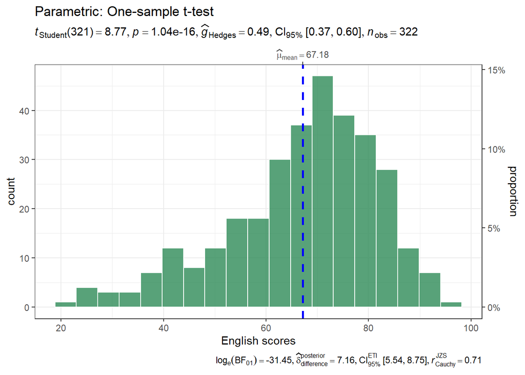

```r
# Parametric (t-test)
set.seed(1234)
gghistostats(
  data = exam,
  x = ENGLISH,
  type = "parametric",
  test.value = 60,
  xlab = "English scores",
  title = "Parametric: One-sample t-test",
  bin.args = list(fill = "seagreen",
                  color = "white",
                  alpha = 0.8)
) + theme_bw()
```

**(ii) 1-sample Wilcoxon signed rank test**

$H_0$: $\mu = 60$ (English scores mean is equal to 60)

$H_1$: $\mu \neq 60$ (English scores mean is not equal to 60)

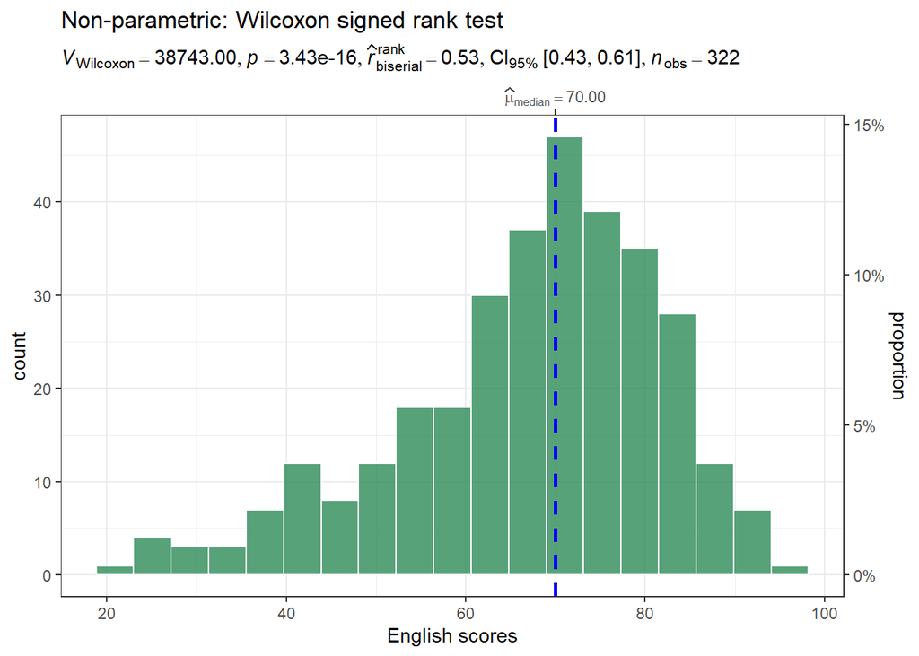

```r
# Non-parametric (Wilcoxon)
set.seed(1234)
gghistostats(
  data = exam,
  x = ENGLISH,
  type = "nonparametric",
  test.value = 60,
  xlab = "English scores",
  title = "Non-parametric: Wilcoxon signed rank test",
  bin.args = list(fill = "seagreen",
                  color = "white",
                  alpha = 0.8)
) + theme_bw()
```

**(iii) 1-sample robust t-test**

$H_0$: $\mu = 60$ (English scores mean is equal to 60)

$H_1$: $\mu \neq 60$ (English scores mean is not equal to 60)

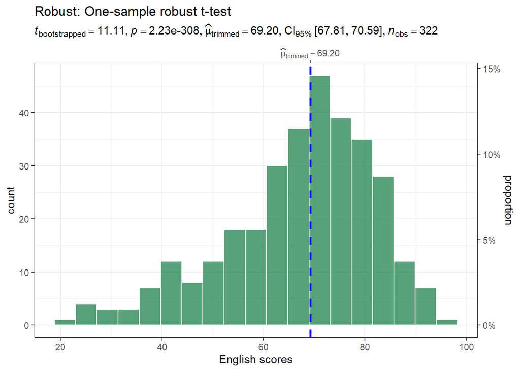

```r
# Robust
set.seed(1234)
gghistostats(
  data = exam,
  x = ENGLISH,
  type = "robust",
  test.value = 60,
  xlab = "English scores",
  title = "Robust: One-sample robust t-test",
  bin.args = list(fill = "seagreen",
                  color = "white",
                  alpha = 0.8)
) + theme_bw()
```

**(iv) Bayes Factor test**

- A Bayes factor is the ratio of the likelihood of one particular hypothesis to the likelihood of another. It can be interpreted as a measure of the strength of evidence in favor of one theory among two competing theories.
- That’s because the Bayes factor gives us a way to evaluate the data in favor of a null hypothesis, and to use external information to do so. It tells us what the weight of the evidence is in favor of a given hypothesis.
- When we are comparing two hypotheses: H1 (the alternate hypothesis) and H0 (the null hypothesis), the Bayes Factor is often written as B10, i.e.,
  $$B_{10} = \frac{P(Data | H_1)}{P(Data | H_0)}$$
- The [Schwarz criterion](https://www.statisticshowto.com/bayesian-information-criterion/) is one of the easiest ways to calculate rough approximation of the Bayes Factor.

| If $B_{10}$ is… | Then you have… |
| --- | --- |
| $> 100$ | Extreme evidence for $H_1$ |
| $30 - 100$ | Very strong evidence for $H_1$ |
| $10 - 30$ | Strong evidence for $H_1$ |
| $3 - 10$ | Moderate evidence for $H_1$ |
| $1 - 3$ | Anecdotal evidence for $H_1$ |
| $1$ | No evidence |
| $1/3 - 1$ | Anecdotal evidence for $H_0$ |
| $1/3 - 1/10$ | Moderate evidence for $H_0$ |
| $1/10 - 1/30$ | Strong evidence for $H_0$ |
| $1/30 - 1/100$ | Very strong evidence for $H_0$ |
| $< 1/100$ | Extreme evidence for $H_0$ |

$H_0$: $\mu = 60$

$H_1$: $\mu \neq 60$

$$B_{10} = \frac{P(Data | H_1)}{P(Data | H_0)}$$

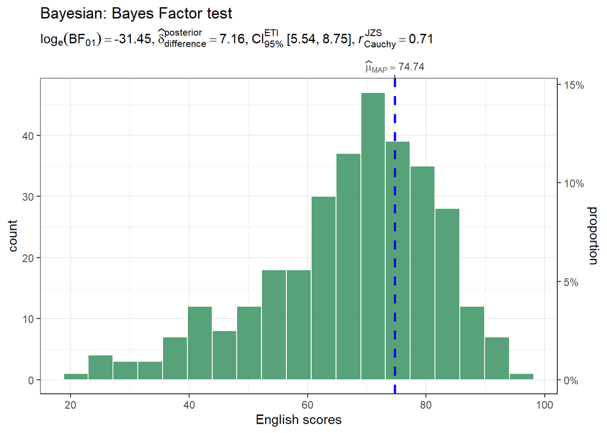

```r
# Bayes
set.seed(1234)
gghistostats(
  data = exam,
  x = ENGLISH,
  type = "bayes",
  test.value = 60,
  xlab = "English scores",
  title = "Bayesian: Bayes Factor test",
  bin.args = list(fill = "seagreen",
                  color = "white",
                  alpha = 0.8)
) + theme_bw()
```

**(b) 2-sample test**

| Type Argument | Test Used | Nature |
| --- | --- | --- |
| `type = "parametric"` | Welch’s t-test | Parametric |
| `type = "nonparametric"` or `type = "np"` | Wilcoxon rank-sum test (Mann-Whitney) | Non-parametric |
| `type = "robust"` | Yuen’s trimmed means t-test | Robust |
| `type = "bayes"` | Bayesian t-test | Bayesian |

**(i) Welch’s t-test**

$H_0$: $\mu_{Female} = \mu_{Male}$ (Mean Math scores of Female and Male are equal)

$H_1$: $\mu_{Female} \neq \mu_{Male}$ (Mean Math scores of Female and Male are not equal)

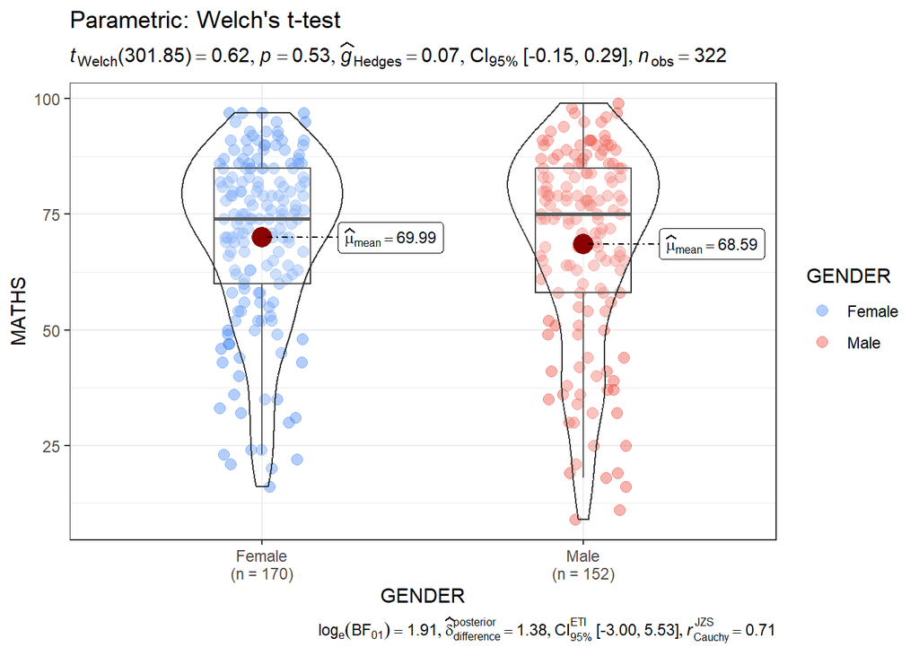

```r
# Parametric (Welch's t-test)
ggbetweenstats(
  data = exam,
  x = GENDER,
  y = MATHS,
  type = "parametric",
  title = "Parametric: Welch's t-test",
  messages = FALSE,
  palette = "Set2",
  package = "RColorBrewer"
) + theme_bw()
```

**(ii) Wilcoxon rank-sum test**

$H_0$: $\mu_{Female} = \mu_{Male}$ (Mean Math scores of Female and Male are equal)

$H_1$: $\mu_{Female} \neq \mu_{Male}$ (Mean Math scores of Female and Male are not equal)

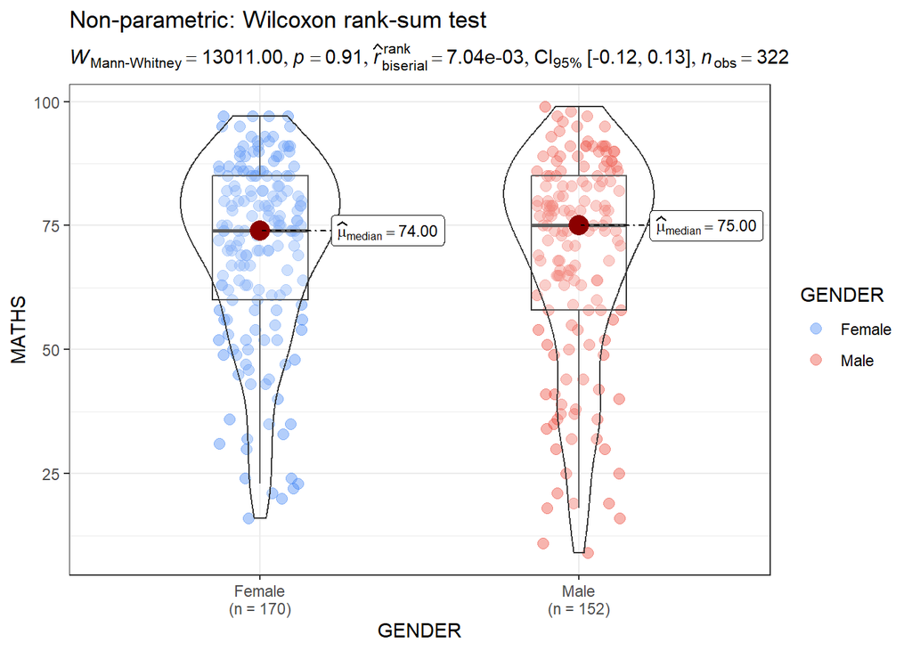

```r
# Non-parametric (Wilcoxon rank-sum)
ggbetweenstats(
  data = exam,
  x = GENDER,
  y = MATHS,
  type = "nonparametric",
  title = "Non-parametric: Wilcoxon rank-sum test",
  messages = FALSE,
  palette = "Set2",
  package = "RColorBrewer"
) + theme_bw()
```

**(iii) Yuen’s trimmed means t-test**

$H_0$: $\mu_{Female} = \mu_{Male}$ (Mean Math scores of Female and Male are equal)

$H_1$: $\mu_{Female} \neq \mu_{Male}$ (Mean Math scores of Female and Male are not equal)

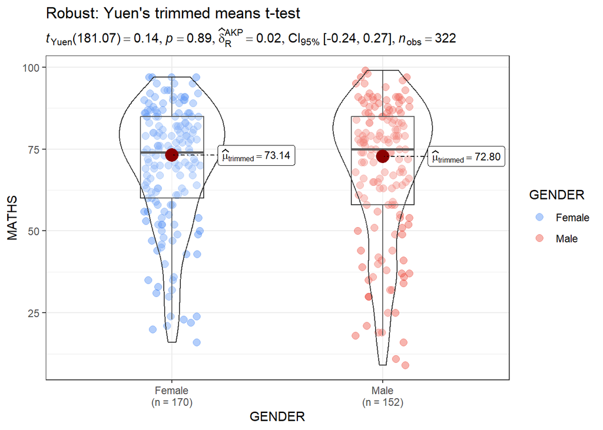

```r
# Robust (Yuen's trimmed means)
ggbetweenstats(
  data = exam,
  x = GENDER,
  y = MATHS,
  type = "robust",
  title = "Robust: Yuen's trimmed means t-test",
  messages = FALSE,
  palette = "Set2",
  package = "RColorBrewer"
) + theme_bw()
```

**(iv) Bayesian t-test**

$H_0$: $\mu_{Female} = \mu_{Male}$

$H_1$: $\mu_{Female} \neq \mu_{Male}$

$$B_{10} = \frac{P(Data | H_1)}{P(Data | H_0)}$$

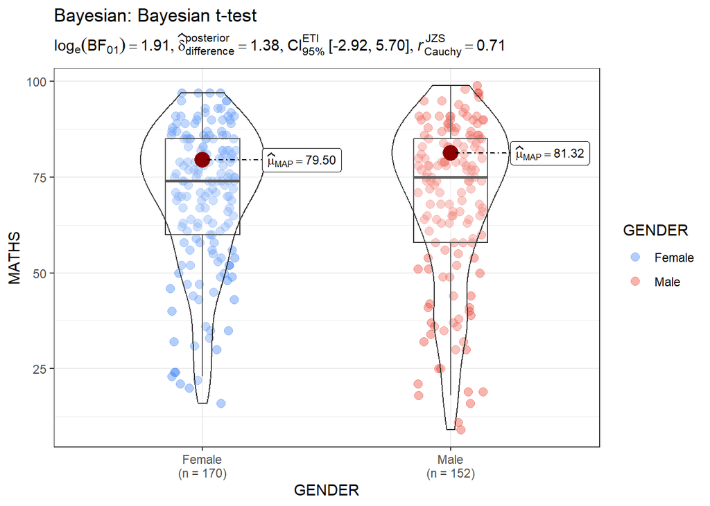

```r
# Bayesian
ggbetweenstats(
  data = exam,
  x = GENDER,
  y = MATHS,
  type = "bayes",
  title = "Bayesian: Bayesian t-test",
  messages = FALSE,
  palette = "Set2",
  package = "RColorBrewer"
) + theme_bw()
```

**(c) 1-way ANOVA**

$H_0$: $\mu_{Chinese} = \mu_{Indian} = \mu_{Malay} = \mu_{Others}$ (Mean English scores of all races are equal)

$H_1$: $\mu$ (Not all mean English scores are equal)

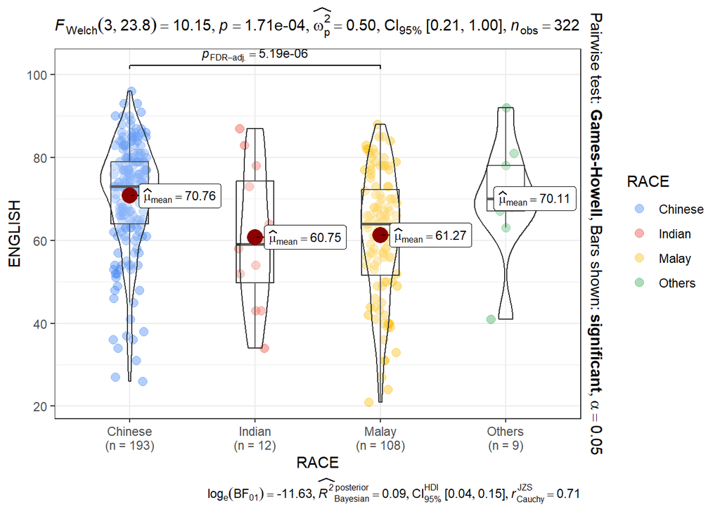

```r
ggbetweenstats(
  data = exam,
  x = RACE,
  y = ENGLISH,
  type = "p",
  mean.ci=TRUE,
  pairwise.comparisons = TRUE,
  pairwise.display = "s",  # 'ns': shows only non-sig, 's': shows only sig, 'all': both
  p.adjust.method = "fdr",
  messages = FALSE
) +
  theme_bw()
```

### 3.2 Correlation

- In the code chunk below, [ggscatterstats()](https://www.indrapatil.com/ggstatsplot/reference/ggscatterstats.html) is used to build a visual for Significant Test of Correlation between Maths scores and English scores.
- `ggscatterstats()` doesn’t have a direct `color` argument for the points. Use point.args instead to pass colour settings to the underlying `geom_point()`

$H_0$: $\rho = 0$ (There is no correlation between Math and English scores)

$H_1$: $\rho \neq 0$ (There is a significant correlation between Math and English scores)

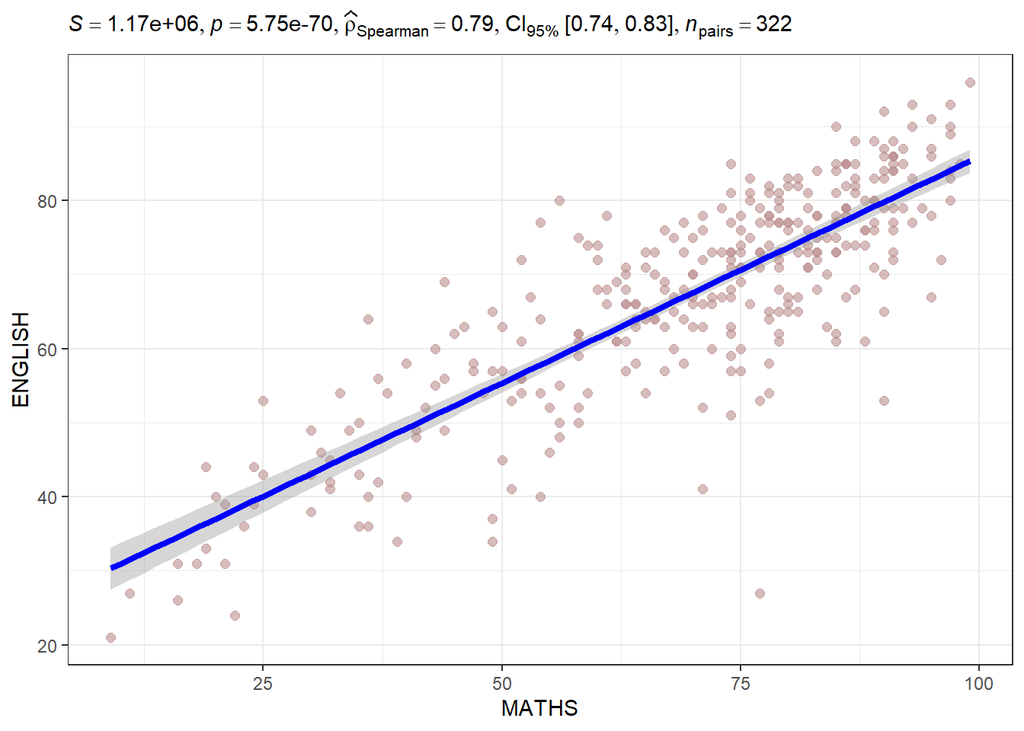

```r
ggscatterstats(
  data = exam,
  x = MATHS,
  y = ENGLISH,
  type = "nonparametric",
  marginal = FALSE,
  point.args = list(color = "rosybrown",
                    size = 2,
                    alpha = 0.6)
) + theme_bw()
```

### 3.3 Association

$H_0$: MATHS_bins and GENDER are independent

$H_1$: MATHS_bins and GENDER are not independent

- we need to mutate the data into bins first using `cut`.
- From the results, since p-value > 0.05 thus we have not enough statistical evidence to reject the null hypothesis that there is not association between the math_bin and gender variables.

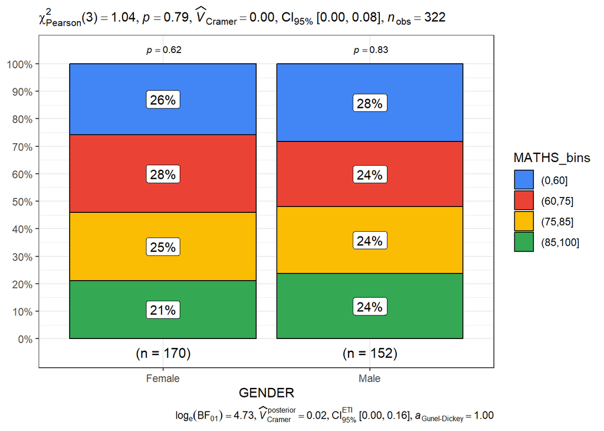

```r
exam1 <- exam %>%
  mutate(MATHS_bins =
           cut(MATHS,
               breaks = c(0,60,75,85,100))
)

ggbarstats(exam1,
            x=MATHS_bins,
            y=GENDER) +

  theme_bw()
```

## 4 Visualising Models

- Import libraries and data (`ToyotaCorolla.csv`)

```r
pacman::p_load(performance, parameters, see)
car_resale <- read_csv("data/ToyotaCorolla.csv")
```

### 4.1 Multiple Regression Model using lm()

- The code chunk below is used to calibrate a multiple linear regression model by using lm() of Base Stats of R.

```r
## transform features
car_resale <- car_resale %>%
  mutate(
    FuelType = as.factor(FuelType),
    MetColor = as.factor(MetColor),
    Automatic = as.factor(Automatic),
    Doors = as.factor(Doors)
  )

## build model
model <- lm(Price ~ Age +
              KM +
              FuelType +
              HP +
              MetColor +
              Automatic +
              CC +
              Doors +
              Weight,
            data = car_resale)
```

### 4.2 Model Diagnostics Visualisations

**(a) multicollinearity**

- In the code chunk, [check_collinearity()](https://easystats.github.io/performance/reference/check_collinearity.html) of [performance](https://easystats.github.io/performance/) package.

```r
check_collinearity(model)
```

```
# Check for Multicollinearity

Low Correlation

      Term  VIF     VIF 95% CI adj. VIF Tolerance Tolerance 95% CI
       Age 1.94 [ 1.81,  2.10]     1.39      0.51     [0.48, 0.55]
        KM 2.01 [ 1.87,  2.18]     1.42      0.50     [0.46, 0.54]
  MetColor 1.02 [ 1.00,  1.23]     1.01      0.98     [0.81, 1.00]
 Automatic 1.09 [ 1.05,  1.18]     1.05      0.91     [0.85, 0.95]
     Doors 1.32 [ 1.24,  1.41]     1.05      0.76     [0.71, 0.80]
    Weight 3.55 [ 3.25,  3.88]     1.88      0.28     [0.26, 0.31]

Moderate Correlation

 Term  VIF     VIF 95% CI adj. VIF Tolerance Tolerance 95% CI
   HP 6.19 [ 5.64,  6.80]     2.49      0.16     [0.15, 0.18]
   CC 8.66 [ 7.87,  9.54]     2.94      0.12     [0.10, 0.13]

High Correlation

     Term   VIF     VIF 95% CI adj. VIF Tolerance Tolerance 95% CI
 FuelType 16.38 [14.83, 18.09]     2.01      0.06     [0.06, 0.07]
```

- render into chart

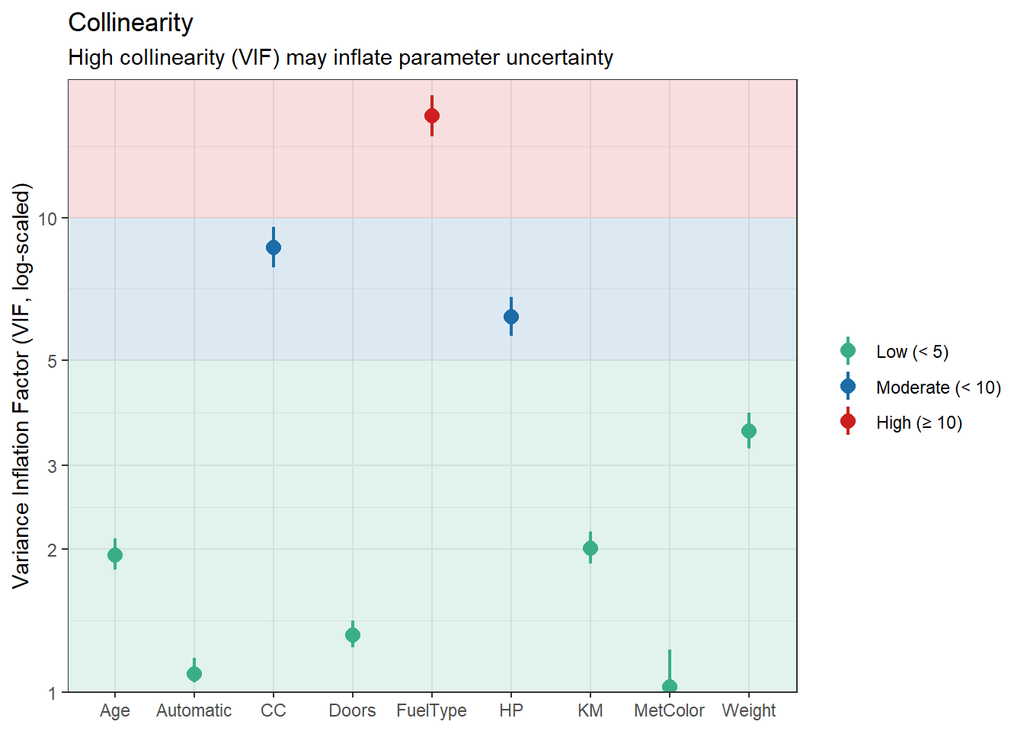

```r
check_c <- check_collinearity(model)
plot(check_c) +
  theme_bw()
```

**(b) normality**

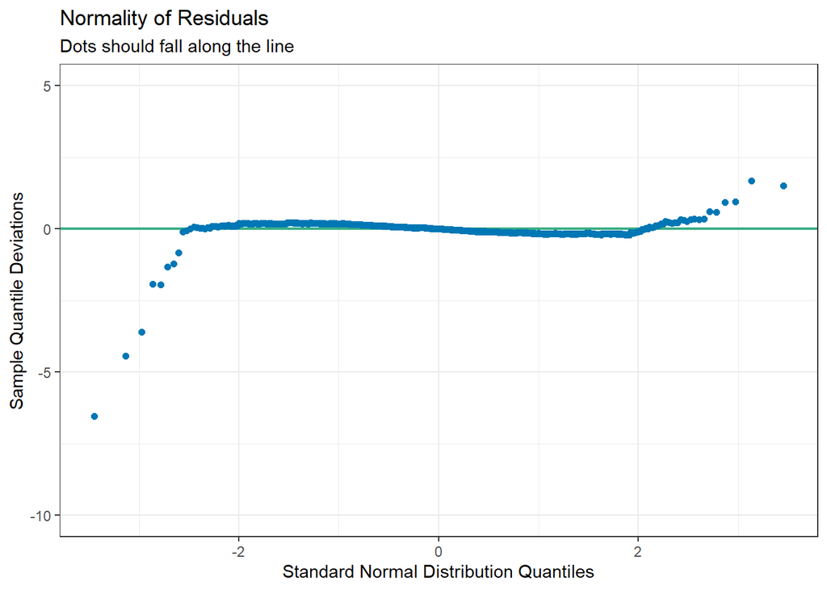

```r
plot(check_normality(model)) + theme_bw()
```

**(c) heteroscedasticity**

In the code chunk, [check_heteroscedasticity()](https://easystats.github.io/performance/reference/check_heteroscedasticity.html) of [performance](https://easystats.github.io/performance/) package.

Heteroscedasticity refers to a situation where the variance of the **errors (or residuals)** in the linear regression model is not constant across different levels of the predictor variable(s).

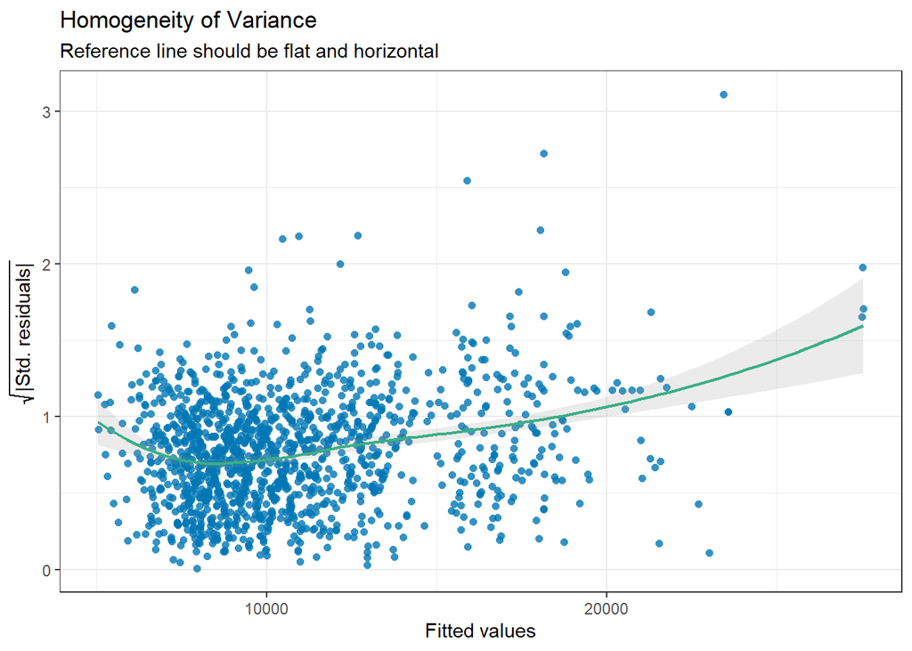

```r
plot(check_heteroscedasticity(model)) + theme_bw()
```

**(d) complete check**

- We can also perform the complete check by using [check_model()](https://easystats.github.io/performance/reference/check_model.html).

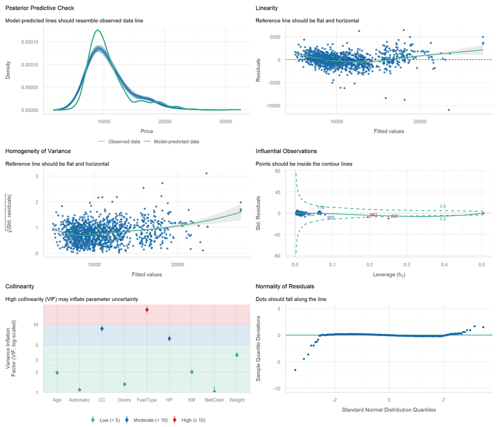

```r
check_model(model)
```

### 4.3 Regression Parameters Visualisations

**(a) see() method**

In the code below, `plot()` of **see** package and `parameters()` of **parameters** package are used to visualise the parameters of a regression model.

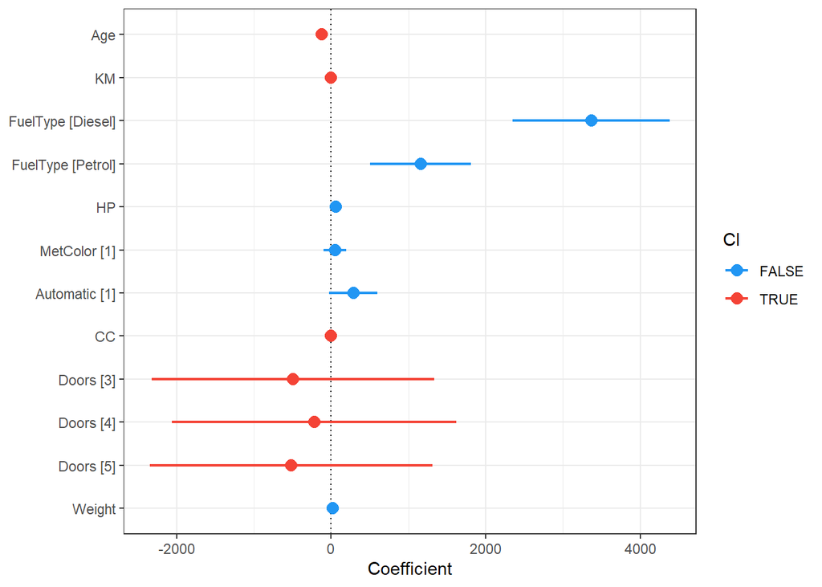

```r
plot(parameters(model)) + theme_bw()
```

**(b) ggcoefstats() method**

In the code below, [ggcoefstats()](https://www.indrapatil.com/ggstatsplot/reference/ggcoefstats.html) of ggstatsplot package to visualise the parameters of a regression model.

- `only.significant = TRUE` shows labels only for variables with p-value < 0.05, reducing clutter significantly!
- Alternatively, we can replace `only.significant = TRUE`with `stats.labels = FALSE`. This removes the cluttered statistical annotation boxes and just shows the coefficient dots and confidence interval lines cleanly.
- Removing non-significant variables can improve the colour contrast of the labels that would otherwise be scaled according to the significance level.

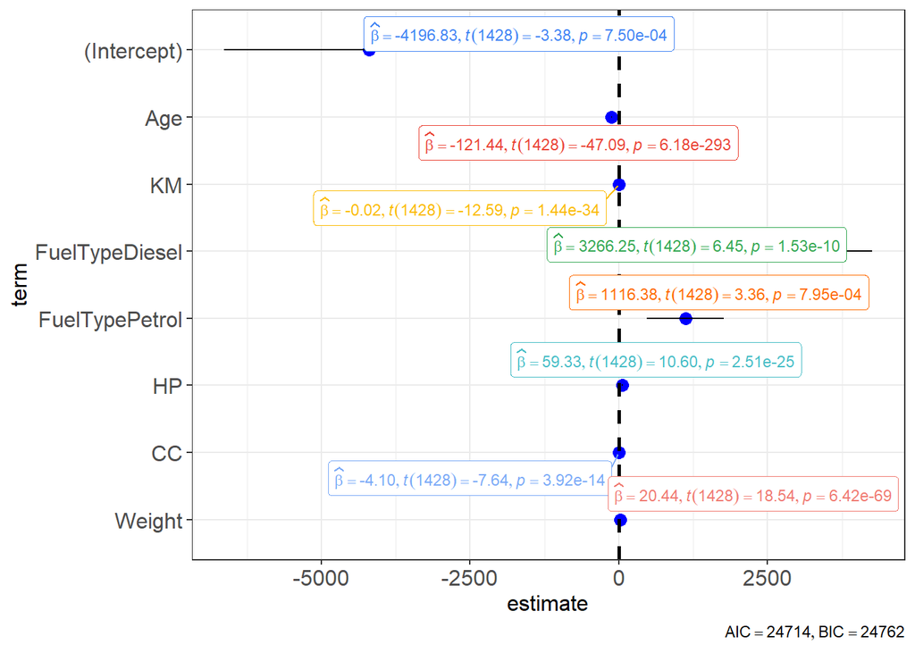

```r
model2 <- lm(Price ~ Age +
               KM +
               FuelType +
               HP +
               CC +
               Weight,
             data = car_resale)

ggcoefstats(model2,
            output = "plot",
            stats.label.args = list(size = 3)) +
  theme_bw() +
  theme(axis.text = element_text(size = 12),
        axis.title = element_text(size = 12))
```

## 5 References

- Kam, T.S. (2023). [Visual Statistical Analysis](https://r4va.netlify.app/chap10).